# 2수준 부분요인설계

## 부분요인설계

- 관심 있는 요인이 많아질수록 실험 설계에 필요한 계산량이 급증
  - 실제로 그 모든 실험을 수행하는 것은 불가능한 경우가 많다.

**1. 계산량 증가의 예**

- 예를 들어, $2^6$ 설계의 경우:
  - 자유도는 63.
  - 주요 효과(main effect)에 대한 것은 6뿐.
  - 두 요인의 교호작용(interaction effect)에 대한 것은 15.
  - 3 요인 이상의 교호작용에 관한 자유도는 42.
    - **결과**: 주 관심이 되는 효과 외에도 계산량이 너무 많음.

**2. 부분요인실험**

- **정의**: 실험자가 합리적인 수준에서 특정 고차 교호작용을 무시할 수 있는 경우, 완전요인실험의 일부만 실행하는 설계를 **부분요인실험(fractional factorial design)** 이라고 함.
- **사용 분야**:
  - 제품 및 프로세스 설계.
  - 공정 개선.
  - 산업 및 비즈니스 실험 분야.

**3. 부분요인실험의 장점**

- 계산량을 줄이며, 주요 효과와 낮은 차수의 교호작용 효과에 집중할 수 있음.
- 실용적이고 널리 사용되는 설계 방법.

## $2^k$ 설계의 $\frac{1}{2}$ 부분

**1. 정의**

- $2^3$ 설계의 경우:
  - 총 8개의 처리조합에 대해 실험을 수행해야 함.
  - 그러나 여러 제약으로 인해 4개의 처리조합만 실행 가능한 경우:
    - 이를 $2^{3-1}$ 설계 또는 $2^3$ 설계의 $\frac{1}{2}$ 부분이라고 함.

**2. 특징**

- $\frac{1}{2}$ 부분 설계는 처리조합의 수를 줄이면서도 주요 효과와 낮은 차수의 교호작용을 분석할 수 있는 설계 방법.
- 실험 비용 절감과 효율성을 제공함.

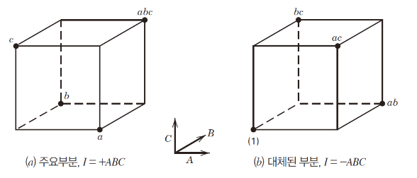

어떤 걸 실제로 하고 어떤 걸 하지 않을지는 다 기준이 있다.

**1. 정의**

- $2^3$ 설계의 경우 총 8개의 처리조합에 대해 실험을 수행해야 하지만,
- 여러 제약으로 인해 4개의 처리조합만 실행 가능한 경우:
  - 이를 $2^{3-1}$ 설계 또는 $2^3$ 설계의 $\frac{1}{2}$ 부분이라 함.

**2. 예시**

| 시행 | $A$ | $B$ | $C$ |
| --- | --- | --- | --- |
| 1 | $+$ | $+$ | $+$ |
| 2 | $+$ | $-$ | $-$ |
| 3 | $-$ | $+$ | $-$ |
| 4 | $-$ | $-$ | $+$ |

**$2^{3-1}$ 설계의 2가지 경우**

1. $2^{3-1}, I = ABC$
   - $C = AB$

| 시행 | $A$ | $B$ | $C = AB$ |
| --- | --- | --- | --- |
| 1 | $+$ | $+$ | $+$ |
| 2 | $+$ | $-$ | $-$ |
| 3 | $-$ | $+$ | $-$ |
| 4 | $-$ | $-$ | $+$ |

- $C$가 $AB$에 종속되어 결정되는 구조이다.
2. $2^{3-1}, I = -ABC$
   - $C = -AB$

| 시행 | $A$ | $B$ | $C = -AB$ |
| --- | --- | --- | --- |
| 1 | $+$ | $+$ | $-$ |
| 2 | $+$ | $-$ | $+$ |
| 3 | $-$ | $+$ | $+$ |
| 4 | $-$ | $-$ | $-$ |

- 마찬가지로 $C$가 $-AB$에 종속되어 결정된다.

**3. 특징**

- $\frac{1}{2}$ 부분 설계는 전체 설계에서 절반의 처리조합만 사용하여 주요 효과와 낮은 차수의 교호작용 분석을 가능하게 함.
- 실험 비용 절감과 효율성을 높이는 설계 방법.

### 예시: $2^4$ 설계의 절반부분설계

**1. 절반부분설계 개요**

- $I = ABCD$인 $2^{4-1}$ 설계의 절반부분설계.

**2. 기본 설계**

| 시행 | $A$ | $B$ | $C$ | $D = ABC$ | 처리조합 | 여과음 |
| --- | --- | --- | --- | --- | --- | --- |
| 1 | $-$ | $-$ | $-$ | $-$ | $(1)$ | 45 |
| 2 | $+$ | $-$ | $-$ | $+$ | $ad$ | 100 |
| 3 | $-$ | $+$ | $-$ | $+$ | $bd$ | 45 |
| 4 | $+$ | $+$ | $-$ | $-$ | $ab$ | 65 |
| 5 | $-$ | $-$ | $+$ | $+$ | $cd$ | 75 |
| 6 | $+$ | $-$ | $+$ | $-$ | $ac$ | 60 |
| 7 | $-$ | $+$ | $+$ | $-$ | $bc$ | 80 |
| 8 | $+$ | $+$ | $+$ | $+$ | $abcd$ | 96 |

(출처: Montgomery, 실험설계 및 분석 제10판, Wiley, 자유아카데미)

**3. 절반부분설계의 제너레이터**

- $2^k$ 설계에서 각 요인은 $(+,-)$ 중 하나로 표현되기 때문에 제곱하면 그냥 $+$로 고정됨에 주의

**제너레이터**:

- $I = ABCD$ (Identity 열과 제너레이터).

**추가 관계식**:

- $A = A^2 BCD = BCD$
- $B = AB^2CD = ACD$
- $C = ABC^2D = ABD$
- $D = ABCD^2 = ABC$

**결론**:

- $AB = CD$
- $AC = BD$
- $BC = AD$

**해석**:

- 등호가 성립하는 처리조합끼리는 요인효과가 중첩됨을 의미한다.
- 즉 처리효과나 유의확률을 계산했을 때 양변의 두 요인들에 대한 정보가 하나의 값에 동시에 존재함을 의미한다.

**4. 특징**

- 절반부분설계를 통해 처리조합의 수를 줄이며 주요 효과와 낮은 차수의 교호작용을 분석 가능.
- 실험 비용 절감과 효율성을 제공하며, 주어진 제너레이터를 통해 추가 관계식을 생성할 수 있음.

**1. 효과 계산**

**$[A]$ 계산** $$ [A] = \frac{1}{4}(100 + 65 + 60 + 96 - 45 - 45 - 75 - 80) $$

- 계산 결과: $$ [A] = 19 \quad \Rightarrow \quad A + BCD $$

**$[AB]$ 계산** $$ [AB] = \frac{1}{4}(45 + 65 + 75 + 96 - 100 - 45 - 60 - 80) $$

- 계산 결과: $$ [AB] = -1 \quad \Rightarrow \quad AB + CD $$

**2. 해석**

- $[A]$: 주요 효과 $A$와 $BCD$ 교호작용의 합.
- $[AB]$: $AB$와 $CD$ 교호작용의 합.
- 절반부분설계에서는 교호작용이 겹쳐서 계산되므로 효과를 분리하기 위해 추가적인 가정이나 모델링이 필요.

**1. 추정치 및 가명 구조**

| 추정치 | 가명 구조 |
| --- | --- |
| $[A] = 19.00$ | $[A] \rightarrow A + BCD$ |
| $[B] = 1.50$ | $[B] \rightarrow B + ACD$ |
| $[C] = 14.00$ | $[C] \rightarrow C + ABD$ |
| $[D] = 16.50$ | $[D] \rightarrow D + ABC$ |
| $[AB] = -1.00$ | $[AB] \rightarrow AB + CD$ |
| $[AC] = -18.50$ | $[AC] \rightarrow AC + BD$ |
| $[AD] = 19.00$ | $[AD] \rightarrow AD + BC$ |

**2. 해석**

**(a) 주요 효과 분석**

- $A$, $C$, $D$는 중요한 효과로 나타남.
- $AC$, $AD$도 중요한 효과일 확률이 높음:
  - $AC + BD$, $AD + BC$가 큰 효과를 가짐.

**(b) $AB$ 효과의 중요성**

- $AB$는 중요하지 않은 효과로 나타남. 그런데 $AB$는 $CD$와 중첩되어 있다.
- 따라서 $AB$와 $CD$ 모두 무시할 만한 효과로 간주 가능.

**회귀식** $$ \hat{y} = \hat{\beta}_0 + \hat{\beta}_1 x_1 + \hat{\beta}_3 x_3 + \hat{\beta}_4 x_4 + \hat{\beta}_{13} x_1 x_3 + \hat{\beta}_{14} x_1 x_4 $$

**계수 대입** $$ \hat{y} = 70.75 + \left(\frac{19.00}{2}\right)x_1 + \left(\frac{14.00}{2}\right)x_3 + \left(\frac{16.50}{2}\right)x_4 - \left(\frac{18.50}{2}\right)x_1 x_3 + \left(\frac{19.00}{2}\right)x_1 x_4 $$

**해석**

- $\hat{\beta}_0$: 상수항으로, 평균값 $70.75$.
- 각 계수는 추정치의 절반값으로 계산됨:
  - $\hat{\beta}_1 = \frac{19.00}{2}$, $\hat{\beta}_3 = \frac{14.00}{2}$, $\hat{\beta}_4 = \frac{16.50}{2}$.
  - 교호작용 계수: $\hat{\beta}_{13} = -\frac{18.50}{2}$, $\hat{\beta}_{14} = \frac{19.00}{2}$.

**1. Identity와 제너레이터 관계** $$ I = -ABCD $$

**2. 주요 효과 관계식**

**A의 관계식** $$ A = -A^2BCD = -BCD $$

**B의 관계식** $$ B = -AB^2CD = -ACD $$

**C의 관계식** $$ C = -ABC^2D = -ABD $$

**D의 관계식** $$ D = -ABCD^2 = -ABC $$

**3. 교호작용 관계식**

- $AB = -CD$
- $AC = -BD$
- $BC = -AD$